# Major League TagPro Player Analysis

Max Gipson

May 18, 2018

## Background

TagPro is an online, flash-based browser game in which two teams of four “balls” compete in Capture-the-Flag. The objective of the game is to keep one’s own flag in base while attempting to grab and capture the other team’s flag. Public games, in which anyone can queue up instantly and begin playing, are won when one team captures the other’s flag three times. After twelve minutes, the team with the lead wins the game, or the game ends in a draw. More information about the game can be found at the official wiki: www.reddit.com/r/Tagpro/wiki, and the game can be played at www.tagpro.gg.

The game officially went online in February of 2013 and has had a steadily-growing playerbase ever since. Although playing in public matches was fun for all, the community craved additional competition. In June of 2013, private games were implemented so that players could challenge and play their friends, but public statistics (e.g. overall wins, total captures) would not be affected. Soon after, the first season of Major League TagPro (MLTP) took place with 16 players split into four teams. Now in its 15th season, MLTP is the highest-caliber league TagPro has to offer, while less-than-stellar players can compete in Minor League TagPro (mLTP) and Novice League TagPro (NLTP). Due to efforts of the community, statistics for every league game (and public game) are recorded in some way or another, with the most popular go-to websites for statistics being www.tagpro.eu, www.tagproleague.com, and www.reddit.com/r/MLTP.

## Dependencies

Apart from the R language (available for free installation here: https://cran.r-project.org/index.html), there are several packages that will aid us in our analysis, notably:

- tidyverse (www.tidyverse.org)
- stringr (https://cran.r-project.org/package=stringr)
- tidyr (https://www.rdocumentation.org/packages/tidyr/versions/0.8.0)
- dplyr (https://dplyr.tidyverse.org/)
- ggplot2 (https://ggplot2.tidyverse.org/reference/)

To set up one’s own R environment, install RStudio, a free R IDE, at https://www.rstudio.com/products/rstudio/download/. From there, installing packages is as easy as navigating to the native console and typing `install.packages("package-name")`. Then we can get to data analysis!

## Data Acquisition and Tidying

In this analysis, we’ll be looking at comparing the top MLTP players from seasons 10 to 14. The MLTP player population was much different five seasons ago, so using the most recent five, hopefully the analysis we perform will be more relevant to the current state of the league. The datasets we’re using were obtained at https://www.tagproleague.com/MLTP/stats by exporting the cumulative Week Stats for seasons 10 through 14.

```r
suppressMessages(library(tidyverse))
library(stringr)
library(tidyr)
library(dplyr)
library(ggplot2)

s10 <- suppressWarnings(suppressMessages(read_csv("final_files\\mltp_season10.csv"))) %>%
  mutate(season=10)
s11 <- suppressWarnings(suppressMessages(read_csv("final_files\\mltp_season11.csv"))) %>%
  mutate(season=11)
s12 <- suppressWarnings(suppressMessages(read_csv("final_files\\mltp_season12.csv"))) %>%
  mutate(season=12)
s13 <- suppressWarnings(suppressMessages(read_csv("final_files\\mltp_season13.csv"))) %>%
  mutate(season=13)
s14 <- suppressWarnings(suppressMessages(read_csv("final_files\\mltp_season14.csv"))) %>%
  mutate(season=14)

# let's get all our entries in one data frame, preserving each individual entry
tagpro <- suppressMessages(s10 %>%
  full_join(s11) %>%
  full_join(s12) %>%
  full_join(s13) %>%
  full_join(s14)) %>%
  # we can remove team because we will not be analyzing team performances, just players
  select(-team, -X28)

# some top players changed their name between seasons
tagpro$player[tagpro$player %in% "ProTagonist_"] <- "protag"
tagpro$player[tagpro$player %in% c("Crippy", "crippy")] <- "badger"

tagpro
```

```
## # A tibble: 500 x 27
##    player       score minutes    pm  tags  pops grabs drops  hold captures
##    <chr>        <int>   <int> <int> <int> <int> <int> <int> <int>    <int>
##  1 Altiger       1462     360     9   357   551   507   459  4078       36
##  2 Blue Dream     143      40   - 5    34    76    67    60   469        4
##  3 Death Pickle  1579     400   -16   604   310   182   174  1461        7
##  4 BigBird       1680     400   - 4   550   284   170   158  1156        6
##  5 Vials         1295     400   -16   286   645   594   542  4400       41
##  6 Mr.Gone       1570     400   -16   557   411   226   212  1604       13
##  7 Sundown       1394     359   - 2   465   299   179   168  1575       10
##  8 dywz          1285     370   - 1   228   594   524   476  3945       46
##  9 yank          1374     344    21   421   289   181   162  1406       16
## 10 YAC            289      80     5    53   122   115   103   930       10
## # ... with 490 more rows, and 17 more variables: prevent <int>,
## #   returns <int>, pups <int>, pupscomp <int>, flaccids <int>,
## #   longholds <int>, handoff <int>, goodhandoff <int>, goregrab <int>,
## #   coregrab <int>, gohandoff <int>, cohandoff <int>, retinbase <int>,
## #   quickret <int>, saves <int>, holdagainst <int>, season <dbl>
```

## Exploratory Data Analysis

The datasets we obtained and combined show statistics recorded by individual players per season. These categories are defined at www.reddit.com/r/Tagpro/wiki/gameplay and www.reddit.com/r/Tagpro/wiki/glossary. TagPro is played using a 2O/2D strategy in which two offensive and two defensive players make up a team. Some stats reflect when a player is better at, or plays more of, one position:

A high-quality offensive player has: - **High** - pm, tags, captures-per-grab, hold, captures, pups - **Low** - pops, drops, flaccids

A high-quality defensive player has: * **High** - pm, tags, prevent, returns, pups * **Low** - pops, holdagainst

The other attributes are also indicative of skill, but those are the best at classifying performance from a statistical perspective.

Let’s looks at the best offensive players of the past five seasons. First, we’ll have to deduce which players are offensively-minded, as that isn’t part of the dataset because players can change positions quite frequently. To do this, we can view the relationship between captures and time played. Using the `group_by` function, we can total players’ individual seasonal statistics by their in-game name. R has excellent documentation, and the `group_by` page can be found here:

https://www.rdocumentation.org/packages/dplyr/versions/0.7.3/topics/group_by

Then, using R’s `ggplot2` package, we can visualize the data. `ggplot2` provides access to a lot of useful functionalities for displaying data graphically in R. See the tidyverse documentation for more information:

http://ggplot2.tidyverse.org/reference/

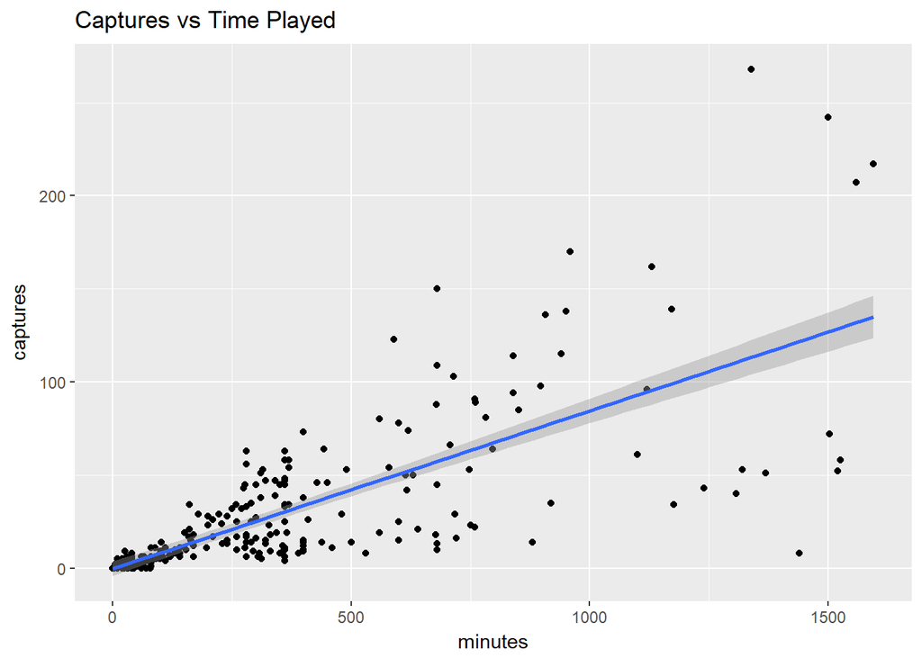

```r
# aggregate individual players' stats over entire dataset
grouped_by_player <- tagpro %>%
  group_by(player) %>%
  summarize_if(is.numeric, sum)

grouped_by_player %>%
  ggplot(aes(x=minutes, y=captures, label=player)) +
    geom_point() +
    labs(title="Captures vs Time Played",
         x = "minutes",
         y = "captures") +
    # we can incorporate a linear regresion model to visualize expected captures
    geom_smooth(method=lm)
```

As one could expect, there is a positive correlation between time spent in-game and captures. Naturally, the more time a player has to score, the greater change they have of doing so. The linear regression line plotted represents the expected captures a player would have given an amount of time spent in-game. For the purposes of this analysis, it is reasonable to assume that players who fall under this line are more defensive, while players over are more offensive. Let’s find out which offenders are the most efficient scorers.

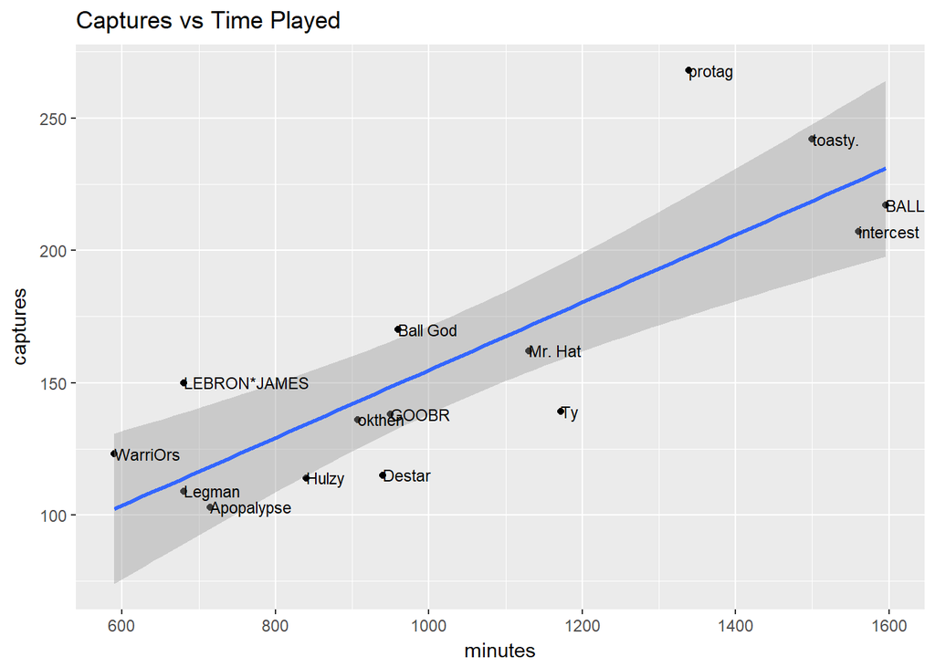

```r
# calculate our linear regression coefficients (e.g. y = ax + b)
captures.lm = lm(captures ~ minutes, data=grouped_by_player)
coeffs <- coefficients(captures.lm)

# take players above the linear regression line
offensive_players <- grouped_by_player %>%
  filter((coeffs[1] + coeffs[2] * minutes < captures))

# get the top 15 players by total captures
top15_off <- offensive_players %>%
  arrange(desc(captures)) %>%
  head(n=15)

# plot our subset
top15_off %>%
  ggplot(aes(x=minutes, y=captures, label=player)) +
    geom_point() +
    labs(title="Captures vs Time Played",
         x = "minutes",
         y = "captures") +
    geom_smooth(method=lm) +
    geom_text(size = 3, hjust=0, nudge_x=0.1, nudge_y = 0.1)
```

In the above plot, we first filtered out the subset of players that were below the original regression line. Of the players with the most captures in our new set (which we can assume to be offensive players), we plotted the capturing efficiencies of the top 15. Again we used a linear regression to provide a baseline for our performances. All of these players are above-average attackers in regard to the rest of the league, but among their subset, it is clear who stands out as making the most of their playing time. LEBRON*JAMES, Ball God, and protag in particular are clearly ahead of the rest of the pack. Rather than eyeball it, we can look at captures per minute to gauge efficiency.

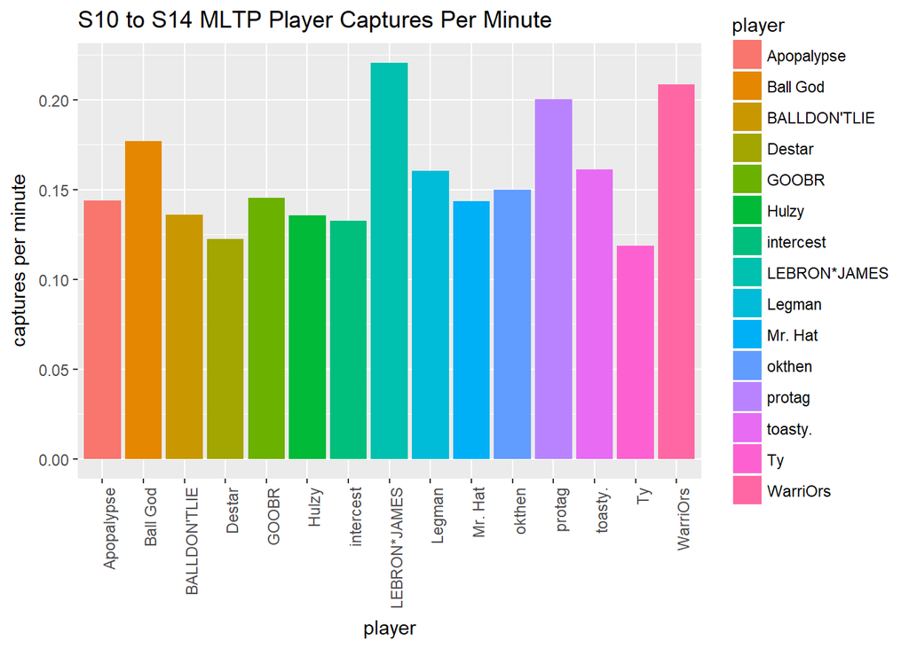

```r
top15_off %>%
  # add a captures-per-minute attribute to the top-15 subset
  mutate(caps_per_min=as.double(captures / minutes)) %>%
  ggplot(aes(x=player, y=caps_per_min)) +
    geom_bar(aes(fill=player), position="dodge", stat="identity") +
    labs(title="S10 to S14 MLTP Player Captures Per Minute",
         x = "player",
         y = "captures per minute") +
  theme(axis.text.x = element_text(angle=90, hjust=1))
```

Here we can see that not only are LEBRON*JAMES, Ball God, and protag offensive players with high captures-per-minute, but so are WarriOrs and toasty. It is important to note that this metric does not depend solely upon the individual player, but also their team. An offender with a poor defense would not be able to capture as often as one with a very good defense that is able to keep their own flag in base so that captures are possible. Let’s look at top defensive players next. We can use the players that were under the linear regression line from earlier, and visualize their returns per minute played, which is indicative of a strong defender that can keep their own flag in base.

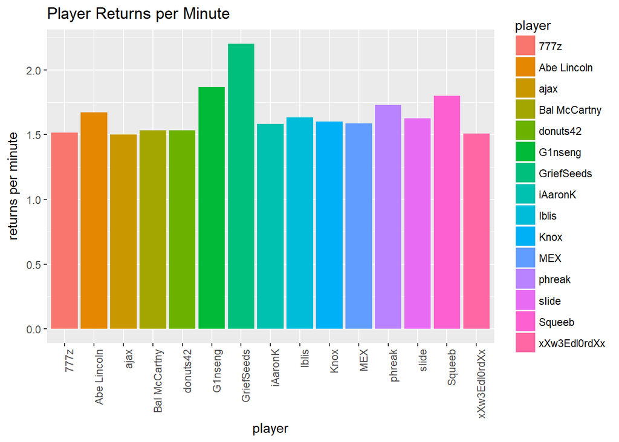

```r
# take players above the linear regression line
defensive_players <- grouped_by_player %>%
  filter((coeffs[1] + coeffs[2] * minutes > captures))

# get the top 15 players by total captures
top15_def <- defensive_players %>%
  mutate(returns_per_min=as.double(returns / minutes)) %>%
  arrange(desc(returns_per_min)) %>%
  head(n=15)

# plot our subset
top15_def %>%
  ggplot(aes(x=player, y=returns_per_min, label=player)) +
    geom_bar(aes(fill=player), position="dodge", stat="identity") +
    labs(title="Player Returns per Minute",
         x = "player",
         y = "returns per minute") +
    theme(axis.text.x = element_text(angle=90, hjust=1))
```

From this data visualization, it is clear that GriefSeeds, G1nseng, Squeeb, phreak, and Abe Lincoln contribute the most returns per minute to their respective teams, compared to other defensive players of similer caliber. This is a totally different group of players because they play a different role than offenders – they aim for returns, not captures.

So far, we’ve only considered captures and returns as defining statistical measurement of offensive and defensive performance, respectively. Let’s come up with a metric to incorporate other attributes to get a real sense for the best offensive and defensive players. Let’s first add some more attributes to our overall dataset. We’ll add:

- captures per minute (as we did with offensive players)
- returns per minute (as we did with defensive players)
- kill death ratio - number of tags divided by number of pops
- non return tags - occur when a player pops a player that is not holding their flag
- non return tags per minute

These will allow us to form a more complete view of how offensive and defensive players perform.

```r
tagpro <- tagpro %>%
  mutate(cpm=as.double(captures / minutes)) %>%
  mutate(rpm=as.double(returns / minutes)) %>%
  mutate(kdr=as.double(tags / pops)) %>%
  mutate(nrt=as.double(tags - returns)) %>%
  mutate(nrtpm=as.double(nrt / minutes))

tagpro %>%
  select(player, cpm, rpm, kdr, nrt, nrtpm) %>%
  head(10)
```

```
## # A tibble: 10 x 6
##    player          cpm   rpm   kdr    nrt nrtpm
##    <chr>         <dbl> <dbl> <dbl>  <dbl> <dbl>
##  1 Altiger      0.100  0.708 0.648 102    0.283
##  2 Blue Dream   0.100  0.700 0.447   6.00 0.150
##  3 Death Pickle 0.0175 1.34  1.95   67.0  0.168
##  4 BigBird      0.0150 1.20  1.94   71.0  0.178
##  5 Vials        0.102  0.475 0.443  96.0  0.240
##  6 Mr.Gone      0.0325 1.26  1.36   53.0  0.132
##  7 Sundown      0.0279 1.13  1.56   61.0  0.170
##  8 dywz         0.124  0.484 0.384  49.0  0.132
##  9 yank         0.0465 1.07  1.46   53.0  0.154
## 10 YAC          0.125  0.438 0.434  18.0  0.225
```

To evaluate these metrics, we’ll compare each players’ individual statistics to the overall mean, and standardize the resulting data to create a ranking for offensive and defensive players. We’ll do so using R’s `scale` and `rank` functions. Learn about them at https://www.rdocumentation.org/packages/base/versions/3.5.0/topics/scale and https://www.rdocumentation.org/packages/base/versions/3.5.0/topics/rank.

The metric we’ll use will combine and weight the offensive stats of captures-per-minute, captures, and hold, based on their contributions to an effective offensive performance.

```r
tagpro_off <- tagpro %>%
  mutate(off_eff=scale(cpm) * 2 + scale(captures) * 5 + scale(hold) * 4)

tagpro_off <- tagpro_off %>%
  mutate(off_rank=rank(off_eff))

tagpro_off %>%
  filter(off_eff != 0) %>%
  select(player, off_rank, off_eff, season) %>%
  arrange(desc(off_rank)) %>%
  head(100)
```

```
## # A tibble: 100 x 4
##    player       off_rank off_eff season
##    <chr>           <dbl>   <dbl>  <dbl>
##  1 LEBRON*JAMES      494    42.8   10.0
##  2 protag            493    37.7   14.0
##  3 WarriOrs          492    35.7   14.0
##  4 Stojakovic        491    32.8   10.0
##  5 protag            490    31.7   10.0
##  6 GOOBR             489    29.3   14.0
##  7 Ball God          488    28.9   10.0
##  8 toasty.           487    28.5   11.0
##  9 Legman            486    28.0   10.0
## 10 fuckthecrc        485    26.4   14.0
## # ... with 90 more rows
```

We’ve derived a metric for offensive ranking of players per season, but let’s see who is consistently good at offense by applying the metric across all seasons.

```r
off_grouped <- tagpro_off %>%
  group_by(player) %>%
  summarise(season=sum(season), off_rank=mean(off_rank)) %>%
  filter(season > 15) %>%
  # summarize_if(is.numeric, sum) %>%
  arrange(desc(off_rank))

top_off_rank <- off_grouped$off_rank[1]

off_grouped %>%
  mutate(off_rank_pct=off_rank / top_off_rank * 100) %>%
  arrange(desc(off_rank_pct)) %>%
  select(player, off_rank_pct) %>%
  head(20)
```

```
## # A tibble: 20 x 2
##    player       off_rank_pct
##    <chr>               <dbl>
##  1 MiIky               100
##  2 LEBRON*JAMES         99.8
##  3 WarriOrs             97.1
##  4 Legman               97.0
##  5 Vials                95.8
##  6 toasty.              94.3
##  7 Mr. Hat              94.0
##  8 Ball God             91.4
##  9 Hulzy                91.1
## 10 Fronj                91.0
## 11 Apopalypse           90.2
## 12 Wanye                90.1
## 13 intercest            90.0
## 14 protag               89.1
## 15 bright               88.0
## 16 okthen               87.3
## 17 BALLDON'TLIE         86.4
## 18 thenewguy.           86.0
## 19 dywz                 85.9
## 20 jjpoole              83.9
```

Now, across the last five seasons, we have a good idea for who the best offenders are, based not only on their captures, but their hold, and other criteria. Bear in mind that the rankings we derived take into account seasons played, so players with longer careers are ranked higher than those who may have stopped playing. A bonus of this ranking is that the disparity in offensive skill is clear. An analyst can see, quantitatively, how much better one player is than another, as opposed to just ranking them 1 through 20.

We can perform the same analysis for defenders. This time we’ll weigh returns-per-minute, kill-death-ratio, non-return-tags-per-minute, and returns accordingly into our metric. This will create an effective way of incorporating defensive stats into an overall defensive ranking.

```r
tagpro_def <- tagpro %>%
  mutate(def_eff=scale(rpm) * 2 + scale(kdr) * 1 + scale(nrtpm) * 2 + scale(returns) * 4 + scale(prevent) * 4)

tagpro_def <- tagpro_def %>%
  mutate(def_rank=rank(def_eff))

tagpro_def %>%
  filter(def_eff != 0) %>%
  select(player, def_rank, def_eff, season) %>%
  arrange(desc(def_rank)) %>%
  head(100)
```

```
## # A tibble: 100 x 4
##    player       def_rank def_eff season
##    <chr>           <dbl>   <dbl>  <dbl>
##  1 GriefSeeds        492    35.5   10.0
##  2 Abe Lincoln       491    29.3   10.0
##  3 intercest         490    27.5   14.0
##  4 Sherrattinho      489    27.4   14.0
##  5 phreak            488    27.2   14.0
##  6 Syniikal          487    26.6   12.0
##  7 MEX               486    26.1   14.0
##  8 badger            485    26.1   14.0
##  9 toasty.           484    25.5   14.0
## 10 YoungSinatra      483    25.3   10.0
## # ... with 90 more rows
```

```r
def_grouped <- tagpro_def %>%
  group_by(player) %>%
  summarise(season=sum(season), def_rank=mean(def_rank)) %>%
  filter(season > 15) %>%
  arrange(desc(def_rank))

top_def_rank <- def_grouped$def_rank[1]

def_grouped %>%
  mutate(def_rank_pct=def_rank / top_def_rank * 100) %>%
  arrange(desc(def_rank_pct)) %>%
  select(player, def_rank_pct) %>%
  head(20)
```

```
## # A tibble: 20 x 2
##    player       def_rank_pct
##    <chr>               <dbl>
##  1 Abe Lincoln         100
##  2 Syniikal             99.3
##  3 Bal McCartny         95.7
##  4 Turbo                95.0
##  5 Iblis                94.8
##  6 SIDE                 94.4
##  7 BigBird              92.4
##  8 siDe                 91.0
##  9 Eashy                90.5
## 10 Mr.Gone              90.5
## 11 iAaronK              90.1
## 12 yank                 89.9
## 13 C Bivvey             88.8
## 14 Arbybear             88.4
## 15 sIide                88.1
## 16 MEX                  87.9
## 17 dodsfall             84.9
## 18 Stann                84.7
## 19 Death Pickle         83.0
## 20 Misaki               83.0
```

```r
tagpro_overall <- off_grouped %>%
  inner_join(def_grouped, by=c("player")) %>%
  mutate(overall_rank=as.double((off_rank + def_rank) / 2)) %>%
  arrange(desc(overall_rank))

top_overall_rank <- tagpro_overall$overall_rank[1]

tagpro_overall <- tagpro_overall %>%
  mutate(overall_rank=as.double(overall_rank / top_overall_rank * 100))

tagpro_overall %>%
  select(player, overall_rank) %>%
  arrange(desc(overall_rank)) %>%
  head(20)
```

```
## # A tibble: 20 x 2
##    player       overall_rank
##    <chr>               <dbl>
##  1 intercest           100
##  2 Altiger              95.1
##  3 WarriOrs             94.9
##  4 Legman               94.5
##  5 jjpoole              92.1
##  6 yank                 92.0
##  7 Abe Lincoln          91.6
##  8 Mr. Hat              91.5
##  9 Mr.Gone              90.9
## 10 BigBird              89.4
## 11 LEBRON*JAMES         88.9
## 12 Apopalypse           88.1
## 13 Vials                88.0
## 14 toasty.              87.9
## 15 Wanye                87.7
## 16 C Bivvey             87.5
## 17 bright               87.4
## 18 Bal McCartny         86.4
## 19 BALLDON'TLIE         86.4
## 20 Arbybear             85.4
```

We can visualize how the number of seasons a player participates in affects their overall ranking. We’ll do so with a scatter plot, after calculating how many seasons each player played in.

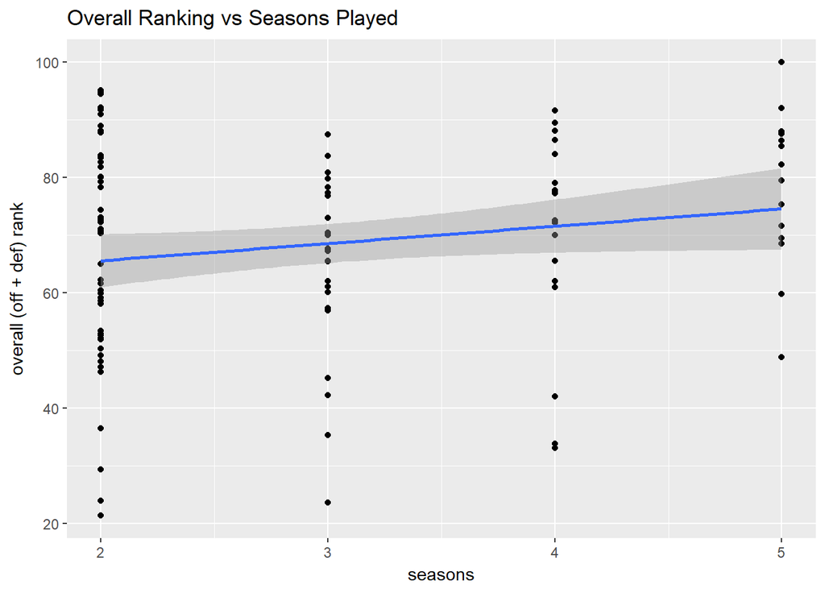

```r
tagpro_overall <- tagpro_overall %>%
  mutate(seasons=ifelse(season.x > 50, 5,
                 ifelse(season.x > 39, 4,
                 ifelse(season.x > 27, 3,
                 ifelse(season.x > 14, 2, 1)))))

tagpro_overall %>%
  ggplot(aes(x=seasons, y=overall_rank, label=player)) +
    geom_point() +
    labs(title="Overall Ranking vs Seasons Played",
         x = "seasons",
         y = "overall (off + def) rank") +
    # we can incorporate a linear regresion model to visualize expected captures
    geom_smooth(method=lm)
```

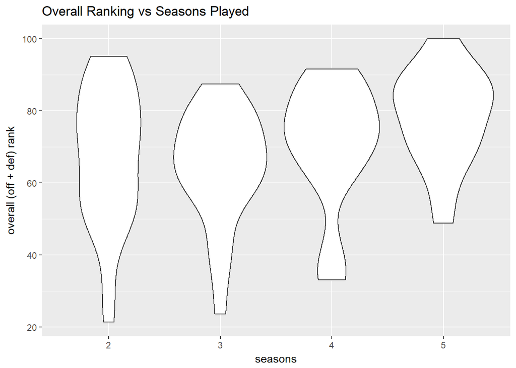

```r
tagpro_overall %>%
  ggplot(aes(x=factor(seasons), y=overall_rank, label=player)) +
    geom_violin() +
    labs(title="Overall Ranking vs Seasons Played",
         x = "seasons",
         y = "overall (off + def) rank") +
    # we can incorporate a linear regresion model to visualize expected captures
    geom_smooth(method=lm)
```

According to this graph, the skill disparity decreases as players participate in more seasons. For players with just two seasons under their belt, the range of overall ratings is much larger, and the rankings are skewed toward poorer players. As number of seasons increases, say to five, the range of overall rankings decreases are less-skilled players get better, and more-skilled players plateau, creating less skew in the data.

We have our analysis comparing players to one another based on offensive and defensive performances across five seasons. Now let’s see who’s the best!

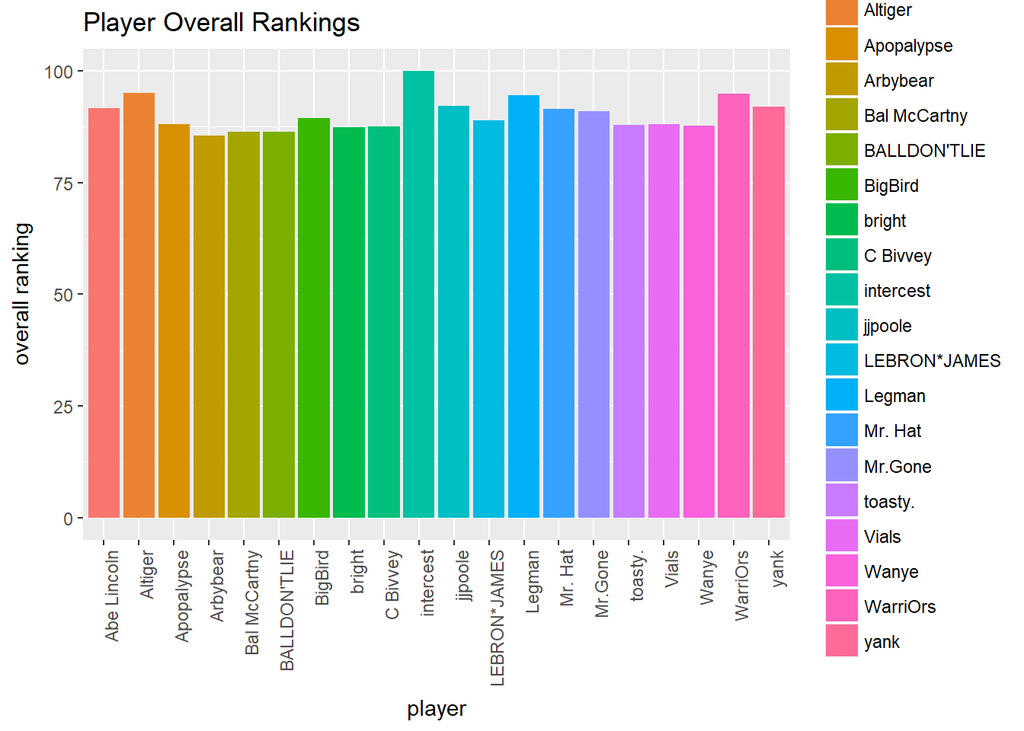

```r
tagpro_overall %>%
  arrange(desc(overall_rank)) %>%
  head(20) %>%
  ggplot(aes(x=player, y=overall_rank, label=player)) +
    geom_bar(aes(fill=player), position="dodge", stat="identity") +
    labs(title="Player Overall Rankings",
         x = "player",
         y = "overall ranking") +
    theme(axis.text.x = element_text(angle=90, hjust=1))
```

Here we have the top 20 players based on the overall ranking metric we used. Any of these players would contribute greatly to a team on both the offensive and defensive ends. Based on the data (and general community opinion), intercest appears to be the greatest player to play the game over the last five seasons.

## Hypothesis Testing and Machine Learning

Given the data we just curated, we could split our dataset into training and testing portions, and use machine learning algorithms to derive predictions for particular outcomes. For example, with Season 15 of MLTP already in progress, we could make a hypothesis that intercest would have the highest overall ranking compared to the other players playing this season. From there, we would be able to find the probability that our hypothesis would come true. A variety of methods can be used to do this, for example decision trees and random forests. Learn about the R `randomForest` package here: https://cran.r-project.org/web/packages/randomForest/randomForest.pdf

## Conclusion

Further analysis could be conducted on this data (with the help of other relevant datasets) to determine how individual players affect how well their teams perform during the regulation season and during playoffs. Further, this analysis could lead to being able to make predictions, with varying degrees of confidence, on which team would win the Superball (much like the Superbowl) for a current season.

In the TagPro community, this analysis would help team captains scout the best players (or players with the most potential) to give their teams a better chance at becoming victorious.